# Lecture 1b: Importing and Tidying Data

Bas Machielsen

3/2/2020

# Introduction

In this lecture, we will occupy ourselves with (i) importing data from a variety of sources, and (ii) tidying the data to make sure the data is ‘tidy’, that is to say, in a format suitable for statistical and graphical analysis, and (iii) manipulating data with dplyr. While importing and tidying data, we will come across various challenges, which I attempt to address.

- You can download the .Rmd file from my **github page**, and follow along!

# Part 1: Importing data - basics

We will start by attempt to import various files that you are used to opening in MS Excel. In R, there is a package, `readxl`, that is specifically optimized to deal with these kinds of files. As you might have noticed, on my Github page, I made a special folder containing several datasets which I use for demonstrative purposes, some of which we will attempt to download and use during this presentation.

First, let us install the `readxl` package.

```r
install.packages('readxl')
```

And don’t forget to ‘turn it on’:

```r
library(readxl)
```

There is a file in https://github.com/basm92/R_Introduction/tree/master/DataFiles called `wb.csv`. If you want, you can download it manually going to the aforementioned github page, click on ‘Raw’, then right click, then ‘Save page as’. However, you might want to be concerned with reproducibility, and if you download something from the internet, it is always good to do this in a reproducible way, for example, by indicating how and when you’ve downloaded the file. Therefore, let’s try to read it from the web!

This is the URL linking to the file:

```r
url <- "https://raw.githubusercontent.com/basm92/R_Introduction/master/DataFiles/wb.csv"
```

and we can read it using the `read.csv` command:

```r
mydata <- read.csv(url)

tibble(mydata)
```

```
## # A tibble: 1,105 x 1
##    mydata$Country.… $Country.Code $Series.Name $Series.Code $X2009..YR2009.
##    <fct>            <fct>         <fct>        <fct>        <fct>
##  1 Argentina        ARG           Adolescent … SP.ADO.TFRT  63.1896
##  2 Argentina        ARG           Agriculture… NV.AGR.TOTL… 5.273623468901…
##  3 Argentina        ARG           Annual fres… ER.H2O.FWTL… ..
##  4 Argentina        ARG           Births atte… SH.STA.BRTC… 97.9
##  5 Argentina        ARG           CO2 emissio… EN.ATM.CO2E… 4.445387802836…
##  6 Argentina        ARG           Contracepti… SP.DYN.CONU… ..
##  7 Argentina        ARG           Domestic cr… FS.AST.DOMS… 25.24733072052
##  8 Argentina        ARG           Electric po… EG.USE.ELEC… 2730.123231631…
##  9 Argentina        ARG           Energy use … EG.USE.PCAP… 1865.337263826…
## 10 Argentina        ARG           Exports of … NE.EXP.GNFS… 19.56098505608…
## # … with 1,095 more rows, and 9 more variables: $X2010..YR2010. <fct>,
## #   $X2011..YR2011. <fct>, $X2012..YR2012. <fct>, $X2013..YR2013. <fct>,
## #   $X2014..YR2014. <fct>, $X2015..YR2015. <fct>, $X2016..YR2016. <fct>,
## #   $X2017..YR2017. <fct>, $X2018..YR2018. <fct>
```

In an appendix to our paper, we might want to indicate when we’ve downloaded something, for example, by including the following chunk:

I’ve downloaded the data from https://raw.githubusercontent.com/basm92/R_Introduction/master/DataFiles/wb.csv on 2020-03-03.

Alternatively, I might want to download the file to my local system, in which case I can use the `download.file` command:

```r
download.file(url, destfile = "wb.csv")
```

..which will download the data directly to my working directory. Then, I proceed to read it in R using `read.csv` in exactly the same way:

```r
mydata <- read.csv("wb.csv")
```

**A little reminder about the syntax: this time, I use "" in read.csv because it is a direct argument, whereas I used read.csv(url) without quotation marks because url is a pointer towards a url, which in turn contains the string towards the real url.**

These data need a lot of cleaning, but let us first inspect the data a little bit more carefully..:

```r
str(mydata)
```

```
## 'data.frame':    1105 obs. of  14 variables:
##  $ Country.Name  : Factor w/ 23 levels "","Argentina",..: 2 2 2 2 2 2 2 2 2 2 ...
##  $ Country.Code  : Factor w/ 21 levels "","ARG","AUS",..: 2 2 2 2 2 2 2 2 2 2 ...
##  $ Series.Name   : Factor w/ 56 levels "","Adolescent fertility rate (births per 1,000 women ages 15-19)",..: 2 3 4 5 6 7 8 9 10 11 ...
##  $ Series.Code   : Factor w/ 56 levels "","AG.LND.FRST.K2",..: 47 25 13 41 11 48 15 9 10 22 ...
##  $ X2009..YR2009.: Factor w/ 857 levels "","-0.0124946312294096",..: 683 619 22 837 565 22 438 462 321 326 ...
##  $ X2010..YR2010.: Factor w/ 855 levels "","-0.12472888164594",..: 678 705 5 822 565 5 419 470 325 312 ...
##  $ X2011..YR2011.: Factor w/ 858 levels "","-0.0197507478863059",..: 674 664 12 840 570 12 429 476 320 300 ...
##  $ X2012..YR2012.: Factor w/ 893 levels "","-0.0730009971601782",..: 708 654 197 878 600 677 521 525 342 279 ...
##  $ X2013..YR2013.: Factor w/ 869 levels "","-0.0353294857608428",..: 679 661 15 842 574 778 530 493 334 245 ...
##  $ X2014..YR2014.: Factor w/ 875 levels "","-0.00454754236383792",..: 698 688 201 868 594 13 547 528 380 245 ...
##  $ X2015..YR2015.: Factor w/ 814 levels "","-0.0218270263170706",..: 665 619 14 811 14 14 576 14 14 127 ...
##  $ X2016..YR2016.: Factor w/ 803 levels "","-0.0321502241110393",..: 653 642 12 12 12 12 541 12 12 197 ...
##  $ X2017..YR2017.: Factor w/ 793 levels "","-0.0792347118224776",..: 647 610 14 14 14 14 545 14 14 173 ...
##  $ X2018..YR2018.: Factor w/ 607 levels "","-0.0129353844507104",..: 10 506 10 10 10 10 10 10 10 165 ...
```

```r
tibble(tail(mydata, 10))
```

```
## # A tibble: 10 x 1
##    `tail(mydata, 1… $Country.Code $Series.Name $Series.Code $X2009..YR2009.
##    <fct>            <fct>         <fct>        <fct>        <fct>
##  1 United States    USA           Tax revenue… GC.TAX.TOTL… 7.919453277415…
##  2 United States    USA           Terrestrial… ER.PTD.TOTL… ..
##  3 United States    USA           Time requir… IC.REG.DURS  ..
##  4 United States    USA           Total debt … DT.TDS.DECT… ..
##  5 United States    USA           Urban popul… SP.URB.GROW  1.085290294288…
##  6 ""               ""            ""           ""           ""
##  7 ""               ""            ""           ""           ""
##  8 ""               ""            ""           ""           ""
##  9 Data from datab… ""            ""           ""           ""
## 10 Last Updated: 1… ""            ""           ""           ""
## # … with 9 more variables: $X2010..YR2010. <fct>, $X2011..YR2011. <fct>,
## #   $X2012..YR2012. <fct>, $X2013..YR2013. <fct>, $X2014..YR2014. <fct>,
## #   $X2015..YR2015. <fct>, $X2016..YR2016. <fct>, $X2017..YR2017. <fct>,
## #   $X2018..YR2018. <fct>
```

The last couple of lines contain metadata, so we might want to erase them. How do we do that? We can use R’s base syntax again, by selecting the number of rows 1 to 1100. Alternatively, we can also use a negative sign to indicate we select everything BUT rows 1101:1105:

```r
mydata <- mydata[-(1101:1105),]
```

## Importing data - .xlsx and .xls

The `readxl` package does not only feature functions to specifically deal with csv files, but also with .xls and .xlsx files. Although not the standard anymore, most of these files are still frequently used and can be found anywhere. We use either `read_xls` or `read_xlsx` to read in the file.

```r
read_xlsx("../DataFiles/sample_excel_file.xlsx") #Try to specify the full path to the file
```

```
## # A tibble: 7 x 3
##    Year Quarter `Stock Prices`
##   <dbl>   <dbl> <chr>
## 1  2015       1 6
## 2  2015       2 7.17
## 3  2015       3 6.17
## 4  2016       1 7.21
## 5  2016       2 7.43
## 6  2016       3 7.76
## 7  2016       4 NA
```

**Exercise**: Try to download the file from [my Github page](https://github.com/basm92/R_Introduction/blob/master/DataFiles/sample_excel_file.xlsx), and load it into R from there.

Both `read_xlsx` and `read_xls` have a number of arguments with default options. Usually, the default options are fine, but sometimes you might want to fine-tune the importing process.

```r
?read_xlsx
```

gives us the following information..

- sheet: you can specify the sheet number here, in case you have an Excel file with multiple sheets. In general, it is not recommended to use sheets, but to you a separate file for all data which you have. They can be merged very easily in R, as we will learn later.
- range: you can specify a range of rows which you want to import.
- col_names: You can specify whether you want to import specific column names or not.
- col_types: This one might be quite important, especially given the limitations of Excel to recognize your data for what it is: you might want to specify the types of variable for each column: character, factor, numeric, et cetera. You can specify one argument for each column. If you specify one argument, it will be recycled, meaning it will repeat itself over all columns. A small example of how this works:

```r
read_xlsx("../DataFiles/sample_excel_file.xlsx", col_types = c("text", "numeric", "numeric"))
```

```
## # A tibble: 7 x 3
##   Year  Quarter `Stock Prices`
##   <chr>   <dbl>          <dbl>
## 1 2015        1           6
## 2 2015        2           7.17
## 3 2015        3           6.17
## 4 2016        1           7.21
## 5 2016        2           7.43
## 6 2016        3           7.76
## 7 2016        4          NA
```

- skip: you can skip a numbe rof rows before reading anything.

There are a couple of other arguments which might be worthwhile to specify in certain situations.

## Importing data - JSON

JSON [JavaScript Object Notation] is a format that is gaining more and more visibility, as various API’s resort to it, partly because it is very easy to use and partly because it takes up very little space. For example, the [Dutch government](https://data.overheid.nl) stores a lot of data in JSON format. I tend to use the package `jsonlite` to import such data.

Let’s take [this](https://data.overheid.nl/dataset/55983-huishoudelijk-afval-per-gemeente-per-inwoner--2001-2014) example data set, about the volume of garbage per municipality per inhabitant from 2001-2014. If we scroll down, we can see ‘Downloadable files’, and click `Download bestand` on the right.

Then, we will see an interface menu that looks something like this:

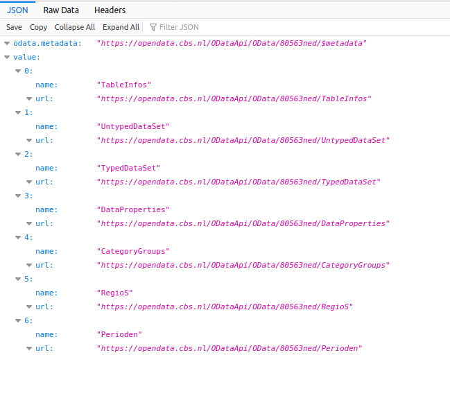

In principle, all of these URL’s contain useful information, but most of them concern metadata, as you might have suspected about `TableInfos`, `DataProperties`, etc. Let’s try to use `jsonlite` to read some of those, and also, let’s read `TypedDataSet` and `UntypedDataSet`.

```r
library(jsonlite)

garbage <- read_json("https://opendata.cbs.nl/ODataApi/OData/80563ned/TableInfos", simplifyVector = TRUE)
```

We used the argument `simplifyVector = TRUE`, which is a very important argument, which allows us to put the second part of the data in a data frame immediately. You might want to verify by omitting the argument and see what you get.

In any case, we have now obtained a list, yet another object in R. A list is an object that can hold in itself objects of different classes. In this case, if you click list, you can verify that it holds a character, containing the URL we’ve just read, and a data.frame, which contains some metadata. If we want to directly access an element in a list, we have to use double brackets [[]] to do so:

```r
garbage <- garbage[[2]]

str(garbage)
```

```
## 'data.frame':    1 obs. of  21 variables:
##  $ ID                 : int 0
##  $ Title              : chr "Huishoudelijk afval per gemeente per inwoner, 2001-2014"
##  $ ShortTitle         : chr "Huishoudelijk afval; gemeente, 2001-2014"
##  $ Identifier         : chr "80563ned"
##  $ Summary            : chr "Hoeveelheden afval per inwoner die door of in opdracht van de gemeenten \nworden ingezameld naar gemeente. "
##  $ Modified           : chr "2015-12-24T02:00:00"
##  $ ReasonDelivery     : chr "Stopgezet"
##  $ ExplanatoryText    : chr ""
##  $ Language           : chr "nl"
##  $ Catalog            : chr "CBS"
##  $ Frequency          : chr "Stopgezet"
##  $ Period             : chr "2001-2014"
##  $ ShortDescription   : chr "\nDeze tabel toont de hoeveelheden ingezameld huishoudelijk afval per gemeente. Deze gegevens zijn verzameld in"| __truncated__
##  $ Description        : chr "INHOUDSOPGAVE\r\n\r\n1. Toelichting\r\n2. Definities en verklaring van symbolen\r\n3. Koppelingen naar relevant"| __truncated__
##  $ DefaultPresentation: chr "graphType=table"
##  $ DefaultSelection   : chr "$filter=((RegioS eq 'GM1680') or (RegioS eq 'GM0193')) and ((Perioden eq '2001JJ00') or (Perioden eq '2002JJ00'"| __truncated__
##  $ GraphTypes         : chr "Table,Map"
##  $ OutputStatus       : chr "Gediscontinueerd"
##  $ Source             : chr "CBS."
##  $ MetaDataModified   : chr "2016-07-15T02:00:00"
##  $ SearchPriority     : chr "1"
```

As we can see, this is some metadata. Let us try to extract the actual data, which is contained in both `UntypedDataSet` and `TypedDataSet`.

```r
garbagedata <- read_json("https://opendata.cbs.nl/ODataApi/OData/80563ned/TypedDataSet", simplifyVector = TRUE)
```

Now, let us overwrite `garbagedata` with just the dataframe, which contains the relevant dataset.

```r
garbagedata <- garbagedata$value

tibble(garbagedata)
```

```
## # A tibble: 7,616 x 1
##    garbagedata$ID $RegioS $Perioden $TotaalHuishoud… $HuishoudelijkR…
##             <int> <chr>   <chr>                <int>            <int>
##  1              0 GM1680  2001JJ00               724              247
##  2              1 GM1680  2002JJ00                NA               NA
##  3              2 GM1680  2003JJ00                NA               NA
##  4              3 GM1680  2004JJ00                NA              280
##  5              4 GM1680  2005JJ00               782              283
##  6              5 GM1680  2006JJ00                NA               NA
##  7              6 GM1680  2007JJ00               700              220
##  8              7 GM1680  2008JJ00               744              274
##  9              8 GM1680  2009JJ00               723              265
## 10              9 GM1680  2010JJ00               682              252
## # … with 7,606 more rows, and 30 more variables:
## #   $GrofHuishoudelijkRestafval_3 <int>, $Verbouwingsrestafval_4 <int>,
## #   $GFTAfval_5 <int>, $OudPapierEnKarton_6 <int>, $Verpakkingsglas_7 <int>,
## #   $Textiel_8 <int>, $KleinChemischAfvalKCA_9 <int>,
## #   $MetalenVerpakkingenBlik_10 <int>, $Drankenkartons_11 <int>,
## #   $KunststofVerpakkingen_12 <int>, $OverigeKunststoffen_13 <int>,
## #   $Luiers_14 <int>, $WitEnBruingoed_15 <int>, $GrofTuinafval_16 <int>,
## #   $BruikbaarHuisraad_17 <int>, $Vloerbedekking_18 <int>, $Vlakglas_19 <int>,
## #   $Metalen_20 <int>, $HoutafvalAEnBHout_21 <int>, $HoutafvalCHout_22 <int>,
## #   $SchoonPuin_23 <int>, $BitumenhoudendeDakbedekking_24 <int>,
## #   $AsbesthoudendAfval_25 <int>, $Autobanden_26 <int>, $SchoneGrond_27 <int>,
## #   $OverigeAfvalstoffen_28 <int>, $Gemeentecode_29 <chr>, $Provincie_30 <chr>,
## #   $Stedelijkheid_31 <chr>, $InwonersPer1Januari_32 <int>
```

There is just once thing which we would like to do: the variable `Regio` contains a code for each municipality. Let us try to extract the supplementary dataset from the API to try to match the codes with actual municipality names.

```r
library(magrittr)
regionnames <- read_json("https://opendata.cbs.nl/ODataApi/OData/80563ned/RegioS",
                         simplifyVector = TRUE) %>%
  extract2(2)
```

Let us attempt to merge the two datasets and see what we get:

```r
mergeddata <- merge(
  garbagedata, regionnames,
  by.x = "RegioS",
  by.y = "Key")

#Let us look at the first 10 rows, and columns 1, 4, 5, and 36.
mergeddata[1:10, c(1,4,5, 36)]
```

```
##    RegioS TotaalHuishoudelijkAfval_1 HuishoudelijkRestafval_2      Title
## 1  GM0003                        590                      311 Appingedam
## 2  GM0003                        611                      324 Appingedam
## 3  GM0003                        676                      320 Appingedam
## 4  GM0003                        705                      309 Appingedam
## 5  GM0003                        672                      312 Appingedam
## 6  GM0003                        658                      225 Appingedam
## 7  GM0003                        688                      228 Appingedam
## 8  GM0003                        674                      234 Appingedam
## 9  GM0003                        701                      237 Appingedam
## 10 GM0003                        654                      232 Appingedam
```

## Importing data - anything else

For any other data you might come across, there are the very general functions `read_table`.and `read_fwf`. Both are very flexible and can read almost any format of data, including some of the ones specified before, but they do not have many default function arguments, so you have to specify many options before it reads the data properly.

For those of you that have Stata, SPSS or SAS data, there is the package **foreign**. You can use the following syntax to install the package and load your Stata, SPSS and SAS files to R.

```r
require(foreign)

spssdata <- read.spss("C:/Dir/spssfile.sav")
statadata <- read.dta("C:/Dir/statafile.dta")
asdata <- read.xport("C:/Dir/sasfile.xpt")
```

**Exercise**: Try to import one of your own data files in R.

Now that we’ve managed to properly import our data, it is time to clean and tidy it.

# Part 2: Tidy data

## What is tidy data?

In order for your data to be ready for analysis, it needs to be **tidy**.

- Tidy data is defined as:

> data sets that are arranged such that each variable is a column and each observation (or case) is a row.

I will attempt to explain how to put this principle in practice using a set of packages called the **tidyverse**, but strictly speaking, only the `dplyr` and the `tidyr` packages are required.

Even more specifically, we will often find ourselves using the Tidyr package, and two functions, `pivot_longer` and `pivot_wider`. In past versions of Tidyr, functions such as `melt`, `spread`, `gather` and `recast` are used. When googling and coming across relevant help on StackOverflow, for example, you will often find references to these commands. Apart from very specific technical tasks, however, it is better to use pivot_longer and pivot_wider now: they are very general, and can be used within almost any context, provided the arguments are specified correctly.

**Exercise**: Is `mergeddata` tidy?

```r
tibble(mergeddata)
```

```
## # A tibble: 7,616 x 1
##    mergeddata$Regi…   $ID $Perioden $TotaalHuishoud… $HuishoudelijkR…
##    <chr>            <int> <chr>                <int>            <int>
##  1 GM0003             364 2001JJ00               590              311
##  2 GM0003             365 2002JJ00               611              324
##  3 GM0003             366 2003JJ00               676              320
##  4 GM0003             367 2004JJ00               705              309
##  5 GM0003             368 2005JJ00               672              312
##  6 GM0003             369 2006JJ00               658              225
##  7 GM0003             370 2007JJ00               688              228
##  8 GM0003             371 2008JJ00               674              234
##  9 GM0003             372 2009JJ00               701              237
## 10 GM0003             373 2010JJ00               654              232
## # … with 7,606 more rows, and 33 more variables:
## #   $GrofHuishoudelijkRestafval_3 <int>, $Verbouwingsrestafval_4 <int>,
## #   $GFTAfval_5 <int>, $OudPapierEnKarton_6 <int>, $Verpakkingsglas_7 <int>,
## #   $Textiel_8 <int>, $KleinChemischAfvalKCA_9 <int>,
## #   $MetalenVerpakkingenBlik_10 <int>, $Drankenkartons_11 <int>,
## #   $KunststofVerpakkingen_12 <int>, $OverigeKunststoffen_13 <int>,
## #   $Luiers_14 <int>, $WitEnBruingoed_15 <int>, $GrofTuinafval_16 <int>,
## #   $BruikbaarHuisraad_17 <int>, $Vloerbedekking_18 <int>, $Vlakglas_19 <int>,
## #   $Metalen_20 <int>, $HoutafvalAEnBHout_21 <int>, $HoutafvalCHout_22 <int>,
## #   $SchoonPuin_23 <int>, $BitumenhoudendeDakbedekking_24 <int>,
## #   $AsbesthoudendAfval_25 <int>, $Autobanden_26 <int>, $SchoneGrond_27 <int>,
## #   $OverigeAfvalstoffen_28 <int>, $Gemeentecode_29 <chr>, $Provincie_30 <chr>,
## #   $Stedelijkheid_31 <chr>, $InwonersPer1Januari_32 <int>, $Title <chr>,
## #   $Description <chr>, $CategoryGroupID <lgl>
```

## Tidyr

- Although tidy data shares the properties mentioned in previously , untidy data refers (broadly speaking) to unstructured data.
- An example (from www.tidyverse.org):

```r
preg <- read.csv("https://raw.githubusercontent.com/tidyverse/tidyr/master/vignettes/preg.csv")

tibble(preg)
```

```
## # A tibble: 3 x 1
##   preg$name    $treatmenta $treatmentb
##   <fct>              <int>       <int>
## 1 John Smith            NA          18
## 2 Jane Doe               4           1
## 3 Mary Johnson           6           7
```

- Is each obervation in a row?
- Is each variable in a column?
- What are the variables here?

```r
preg2 <- read.csv("https://raw.githubusercontent.com/tidyverse/tidyr/master/vignettes/preg2.csv")

tibble(preg2)
```

```
## # A tibble: 2 x 1
##   preg2$treatment $John.Smith $Jane.Doe $Mary.Johnson
##   <fct>                 <int>     <int>         <int>
## 1 a                        NA         4             6
## 2 b                        18         1             7
```

The variables in this dataset are (i) the treatment, (ii) the subject, and (iii) the ‘score’ corresponding to each subject-treatment observations. Let’s see what we can do to transform the data from untidy to tidy data.

```r
library(dplyr)
library(tidyr)

tibble(preg)
```

```
## # A tibble: 3 x 1
##   preg$name    $treatmenta $treatmentb
##   <fct>              <int>       <int>
## 1 John Smith            NA          18
## 2 Jane Doe               4           1
## 3 Mary Johnson           6           7
```

```r
preg %>%
    pivot_longer(treatmenta:treatmentb,
                 names_to = "treatment",
                 values_to = "score")
```

```
## # A tibble: 6 x 3
##   name         treatment  score
##   <fct>        <chr>      <int>
## 1 John Smith   treatmenta    NA
## 2 John Smith   treatmentb    18
## 3 Jane Doe     treatmenta     4
## 4 Jane Doe     treatmentb     1
## 5 Mary Johnson treatmenta     6
## 6 Mary Johnson treatmentb     7
```

The key command in the former chunk of code is `pivot_longer`, with the arguements data, columns, names_to and values_to. Why is pivot_longer called pivot_longer? Because it increases the number of rows.

It takes **columns** , as specified in the first argument, and rearranges them in rows according to each subject. Instead of using column names, you can also use numbers. Then, `names_to` gives a name to the column now containing variables, and values_to gives a name to the column containing the corresponding values.

Let’s us try to give some more examples (from https://tidyr.tidyverse.org/reference/pivot_longer.html):

Here is a dataset called `relig_income`:

```r
tibble(relig_income)
```

```
## # A tibble: 18 x 1
##    relig_income$re… $`<$10k` $`$10-20k` $`$20-30k` $`$30-40k` $`$40-50k`
##    <chr>               <dbl>      <dbl>      <dbl>      <dbl>      <dbl>
##  1 Agnostic               27         34         60         81         76
##  2 Atheist                12         27         37         52         35
##  3 Buddhist               27         21         30         34         33
##  4 Catholic              418        617        732        670        638
##  5 Don’t know/refu…       15         14         15         11         10
##  6 Evangelical Prot      575        869       1064        982        881
##  7 Hindu                   1          9          7          9         11
##  8 Historically Bl…      228        244        236        238        197
##  9 Jehovah's Witne…       20         27         24         24         21
## 10 Jewish                 19         19         25         25         30
## 11 Mainline Prot         289        495        619        655        651
## 12 Mormon                 29         40         48         51         56
## 13 Muslim                  6          7          9         10          9
## 14 Orthodox               13         17         23         32         32
## 15 Other Christian         9          7         11         13         13
## 16 Other Faiths           20         33         40         46         49
## 17 Other World Rel…        5          2          3          4          2
## 18 Unaffiliated          217        299        374        365        341
## # … with 5 more variables: $`$50-75k` <dbl>, $`$75-100k` <dbl>,
## #   $`$100-150k` <dbl>, $`>150k` <dbl>, $`Don't know/refused` <dbl>
```

This data are untidy. There are three variables, Religion, income and count (frequency). Let us try to rearrange the data using `pivot_longer`:

```r
relig_income %>%
  pivot_longer(2:11,
               names_to = "income",
               values_to = "count") %>%
  tibble()
```

```
## # A tibble: 180 x 1
##    .$religion $income            $count
##    <chr>      <chr>               <dbl>
##  1 Agnostic   <$10k                  27
##  2 Agnostic   $10-20k                34
##  3 Agnostic   $20-30k                60
##  4 Agnostic   $30-40k                81
##  5 Agnostic   $40-50k                76
##  6 Agnostic   $50-75k               137
##  7 Agnostic   $75-100k              122
##  8 Agnostic   $100-150k             109
##  9 Agnostic   >150k                  84
## 10 Agnostic   Don't know/refused     96
## # … with 170 more rows
```

Here is another dataset on music charts: billboard.

```r
tibble(billboard)
```

```
## # A tibble: 317 x 1
##    billboard$artist $track $date.entered  $wk1  $wk2  $wk3  $wk4  $wk5  $wk6
##    <chr>            <chr>  <date>        <dbl> <dbl> <dbl> <dbl> <dbl> <dbl>
##  1 2 Pac            Baby … 2000-02-26       87    82    72    77    87    94
##  2 2Ge+her          The H… 2000-09-02       91    87    92    NA    NA    NA
##  3 3 Doors Down     Krypt… 2000-04-08       81    70    68    67    66    57
##  4 3 Doors Down     Loser  2000-10-21       76    76    72    69    67    65
##  5 504 Boyz         Wobbl… 2000-04-15       57    34    25    17    17    31
##  6 98^0             Give … 2000-08-19       51    39    34    26    26    19
##  7 A*Teens          Danci… 2000-07-08       97    97    96    95   100    NA
##  8 Aaliyah          I Don… 2000-01-29       84    62    51    41    38    35
##  9 Aaliyah          Try A… 2000-03-18       59    53    38    28    21    18
## 10 Adams, Yolanda   Open … 2000-08-26       76    76    74    69    68    67
## # … with 307 more rows, and 70 more variables: $wk7 <dbl>, $wk8 <dbl>,
## #   $wk9 <dbl>, $wk10 <dbl>, $wk11 <dbl>, $wk12 <dbl>, $wk13 <dbl>,
## #   $wk14 <dbl>, $wk15 <dbl>, $wk16 <dbl>, $wk17 <dbl>, $wk18 <dbl>,
## #   $wk19 <dbl>, $wk20 <dbl>, $wk21 <dbl>, $wk22 <dbl>, $wk23 <dbl>,
## #   $wk24 <dbl>, $wk25 <dbl>, $wk26 <dbl>, $wk27 <dbl>, $wk28 <dbl>,
## #   $wk29 <dbl>, $wk30 <dbl>, $wk31 <dbl>, $wk32 <dbl>, $wk33 <dbl>,
## #   $wk34 <dbl>, $wk35 <dbl>, $wk36 <dbl>, $wk37 <dbl>, $wk38 <dbl>,
## #   $wk39 <dbl>, $wk40 <dbl>, $wk41 <dbl>, $wk42 <dbl>, $wk43 <dbl>,
## #   $wk44 <dbl>, $wk45 <dbl>, $wk46 <dbl>, $wk47 <dbl>, $wk48 <dbl>,
## #   $wk49 <dbl>, $wk50 <dbl>, $wk51 <dbl>, $wk52 <dbl>, $wk53 <dbl>,
## #   $wk54 <dbl>, $wk55 <dbl>, $wk56 <dbl>, $wk57 <dbl>, $wk58 <dbl>,
## #   $wk59 <dbl>, $wk60 <dbl>, $wk61 <dbl>, $wk62 <dbl>, $wk63 <dbl>,
## #   $wk64 <dbl>, $wk65 <dbl>, $wk66 <lgl>, $wk67 <lgl>, $wk68 <lgl>,
## #   $wk69 <lgl>, $wk70 <lgl>, $wk71 <lgl>, $wk72 <lgl>, $wk73 <lgl>,
## #   $wk74 <lgl>, $wk75 <lgl>, $wk76 <lgl>
```

This data contains various variables, artist, track, date entered, week, and position. Week, however, is not arranged according to the tidy data principle. Let us try to use pivot_longer to tidy this dataset:

```r
billboard %>%
  pivot_longer(cols = starts_with("wk"),
               names_to = "week",
               values_to = "position",
               values_drop_na = TRUE) %>%
  tibble()
```

```
## # A tibble: 5,307 x 1
##    .$artist $track                  $date.entered $week $position
##    <chr>    <chr>                   <date>        <chr>     <dbl>
##  1 2 Pac    Baby Don't Cry (Keep... 2000-02-26    wk1          87
##  2 2 Pac    Baby Don't Cry (Keep... 2000-02-26    wk2          82
##  3 2 Pac    Baby Don't Cry (Keep... 2000-02-26    wk3          72
##  4 2 Pac    Baby Don't Cry (Keep... 2000-02-26    wk4          77
##  5 2 Pac    Baby Don't Cry (Keep... 2000-02-26    wk5          87
##  6 2 Pac    Baby Don't Cry (Keep... 2000-02-26    wk6          94
##  7 2 Pac    Baby Don't Cry (Keep... 2000-02-26    wk7          99
##  8 2Ge+her  The Hardest Part Of ... 2000-09-02    wk1          91
##  9 2Ge+her  The Hardest Part Of ... 2000-09-02    wk2          87
## 10 2Ge+her  The Hardest Part Of ... 2000-09-02    wk3          92
## # … with 5,297 more rows
```

Notice that we used the argument `values_drop_na` to specify that NA observations could be dropped. Remove the argument from the command, and see what the dataset looks like if you don’t specify it.

Now, let’s use the other command that we will use frequently, often in conjunction with `pivot_longer`: `pivot_wider`.

From the tidyverse website:

> pivot_wider() “widens” data, increasing the number of columns and decreasing the number of rows.

Let us see how that works by introducing a small example from US rent incomes:

```r
us_rent_income
```

```
## # A tibble: 104 x 5
##    GEOID NAME       variable estimate   moe
##    <chr> <chr>      <chr>       <dbl> <dbl>
##  1 01    Alabama    income      24476   136
##  2 01    Alabama    rent          747     3
##  3 02    Alaska     income      32940   508
##  4 02    Alaska     rent         1200    13
##  5 04    Arizona    income      27517   148
##  6 04    Arizona    rent          972     4
##  7 05    Arkansas   income      23789   165
##  8 05    Arkansas   rent          709     5
##  9 06    California income      29454   109
## 10 06    California rent         1358     3
## # … with 94 more rows
```

```r
us_rent_income %>%
  pivot_wider(names_from = variable,
              values_from = c("estimate", "moe"))
```

```
## # A tibble: 52 x 6
##    GEOID NAME                 estimate_income estimate_rent moe_income moe_rent
##    <chr> <chr>                          <dbl>         <dbl>      <dbl>    <dbl>
##  1 01    Alabama                        24476           747        136        3
##  2 02    Alaska                         32940          1200        508       13
##  3 04    Arizona                        27517           972        148        4
##  4 05    Arkansas                       23789           709        165        5
##  5 06    California                     29454          1358        109        3
##  6 08    Colorado                       32401          1125        109        5
##  7 09    Connecticut                    35326          1123        195        5
##  8 10    Delaware                       31560          1076        247       10
##  9 11    District of Columbia           43198          1424        681       17
## 10 12    Florida                        25952          1077         70        3
## # … with 42 more rows
```

Pivot_wider usually only takes two arguments:

- names_from: A pair of arguments describing which column (or columns) to get the name of the output column
- values_from: which column (or columns) to get the cell values from

Let us provide another example, `mydata`, which we have loaded before:

```r
tibble(mydata)
```

```
## # A tibble: 1,100 x 1
##    mydata$Country.… $Country.Code $Series.Name $Series.Code $X2009..YR2009.
##    <fct>            <fct>         <fct>        <fct>        <fct>
##  1 Argentina        ARG           Adolescent … SP.ADO.TFRT  63.1896
##  2 Argentina        ARG           Agriculture… NV.AGR.TOTL… 5.273623468901…
##  3 Argentina        ARG           Annual fres… ER.H2O.FWTL… ..
##  4 Argentina        ARG           Births atte… SH.STA.BRTC… 97.9
##  5 Argentina        ARG           CO2 emissio… EN.ATM.CO2E… 4.445387802836…
##  6 Argentina        ARG           Contracepti… SP.DYN.CONU… ..
##  7 Argentina        ARG           Domestic cr… FS.AST.DOMS… 25.24733072052
##  8 Argentina        ARG           Electric po… EG.USE.ELEC… 2730.123231631…
##  9 Argentina        ARG           Energy use … EG.USE.PCAP… 1865.337263826…
## 10 Argentina        ARG           Exports of … NE.EXP.GNFS… 19.56098505608…
## # … with 1,090 more rows, and 9 more variables: $X2010..YR2010. <fct>,
## #   $X2011..YR2011. <fct>, $X2012..YR2012. <fct>, $X2013..YR2013. <fct>,
## #   $X2014..YR2014. <fct>, $X2015..YR2015. <fct>, $X2016..YR2016. <fct>,
## #   $X2017..YR2017. <fct>, $X2018..YR2018. <fct>
```

```r
mydata %>%
  pivot_longer(starts_with("X"),
               names_to = "years",
               values_to = "value")
```

```
## # A tibble: 11,000 x 6
##    Country.Name Country.Code Series.Name               Series.Code years   value
##    <fct>        <fct>        <fct>                     <fct>       <chr>   <fct>
##  1 Argentina    ARG          Adolescent fertility rat… SP.ADO.TFRT X2009.… 63.1…
##  2 Argentina    ARG          Adolescent fertility rat… SP.ADO.TFRT X2010.… 63.3…
##  3 Argentina    ARG          Adolescent fertility rat… SP.ADO.TFRT X2011.… 63.4…
##  4 Argentina    ARG          Adolescent fertility rat… SP.ADO.TFRT X2012.… 63.5…
##  5 Argentina    ARG          Adolescent fertility rat… SP.ADO.TFRT X2013.… 63.41
##  6 Argentina    ARG          Adolescent fertility rat… SP.ADO.TFRT X2014.… 63.2…
##  7 Argentina    ARG          Adolescent fertility rat… SP.ADO.TFRT X2015.… 63.0…
##  8 Argentina    ARG          Adolescent fertility rat… SP.ADO.TFRT X2016.… 62.9…
##  9 Argentina    ARG          Adolescent fertility rat… SP.ADO.TFRT X2017.… 62.7…
## 10 Argentina    ARG          Adolescent fertility rat… SP.ADO.TFRT X2018.… ..
## # … with 10,990 more rows
```

```r
mydata %>%
  pivot_longer(starts_with("X"),
               names_to = "year",
               values_to = "value") %>%
  pivot_wider(names_from = "Series.Code",
              values_from = "value") %>%
  tibble()
```

```
## # A tibble: 11,000 x 1
##    .$Country.Name $Country.Code $Series.Name $year $SP.ADO.TFRT $NV.AGR.TOTL.ZS
##    <fct>          <fct>         <fct>        <chr> <fct>        <fct>
##  1 Argentina      ARG           Adolescent … X200… 63.1896      <NA>
##  2 Argentina      ARG           Adolescent … X201… 63.3154      <NA>
##  3 Argentina      ARG           Adolescent … X201… 63.4412      <NA>
##  4 Argentina      ARG           Adolescent … X201… 63.567       <NA>
##  5 Argentina      ARG           Adolescent … X201… 63.41        <NA>
##  6 Argentina      ARG           Adolescent … X201… 63.253       <NA>
##  7 Argentina      ARG           Adolescent … X201… 63.096       <NA>
##  8 Argentina      ARG           Adolescent … X201… 62.939       <NA>
##  9 Argentina      ARG           Adolescent … X201… 62.782       <NA>
## 10 Argentina      ARG           Adolescent … X201… ..           <NA>
## # … with 10,990 more rows, and 53 more variables: $ER.H2O.FWTL.ZS <fct>,
## #   $SH.STA.BRTC.ZS <fct>, $EN.ATM.CO2E.PC <fct>, $SP.DYN.CONU.ZS <fct>,
## #   $FS.AST.DOMS.GD.ZS <fct>, $EG.USE.ELEC.KH.PC <fct>,
## #   $EG.USE.PCAP.KG.OE <fct>, $NE.EXP.GNFS.ZS <fct>, $DT.DOD.DECT.CD <fct>,
## #   $SP.DYN.TFRT.IN <fct>, $BX.KLT.DINV.CD.WD <fct>, $AG.LND.FRST.K2 <fct>,
## #   $NY.GDP.MKTP.CD <fct>, $NY.GDP.MKTP.KD.ZG <fct>, $NY.GNP.PCAP.CD <fct>,
## #   $NY.GNP.PCAP.PP.CD <fct>, $NY.GNP.ATLS.CD <fct>, $NY.GNP.MKTP.PP.CD <fct>,
## #   $NE.GDI.TOTL.ZS <fct>, $TX.VAL.TECH.MF.ZS <fct>, $SH.IMM.MEAS <fct>,
## #   $NE.IMP.GNFS.ZS <fct>, $SI.DST.FRST.20 <fct>, $NV.IND.TOTL.ZS <fct>,
## #   $NY.GDP.DEFL.KD.ZG <fct>, $SP.DYN.LE00.IN <fct>, $TG.VAL.TOTL.GD.ZS <fct>,
## #   $MS.MIL.XPND.GD.ZS <fct>, $IT.CEL.SETS.P2 <fct>, $SH.DYN.MORT <fct>,
## #   $TT.PRI.MRCH.XD.WD <fct>, $SM.POP.NETM <fct>, $DT.ODA.ALLD.CD <fct>,
## #   $BX.TRF.PWKR.CD.DT <fct>, $EN.POP.DNST <fct>, $SP.POP.GROW <fct>,
## #   $SP.POP.TOTL <fct>, $SI.POV.DDAY <fct>, $SI.POV.NAHC <fct>,
## #   $SH.DYN.AIDS.ZS <fct>, $SH.STA.MALN.ZS <fct>, $SE.PRM.CMPT.ZS <fct>,
## #   $GC.REV.XGRT.GD.ZS <fct>, $SE.PRM.ENRR <fct>, $SE.ENR.PRSC.FM.ZS <fct>,
## #   $SE.SEC.ENRR <fct>, $IQ.SCI.OVRL <fct>, $AG.SRF.TOTL.K2 <fct>,
## #   $GC.TAX.TOTL.GD.ZS <fct>, $ER.PTD.TOTL.ZS <fct>, $IC.REG.DURS <fct>,
## #   $DT.TDS.DECT.EX.ZS <fct>, $SP.URB.GROW <fct>
```

In this chunk, we have first expanded the data by putting `years` back into a column, and put the corresponding values of that variable into a column called `value`. Afterwards, we used the piping operator %>% to expand the dataset by putting all names from Series_code into new columns, and we took the corresponding value from the value column which we’ve just created. I guarentee that 95% of the data transformation operations that you need to do can be done using either pivot_longer, pivot_wider, or a combination of those two!

## Summarizing..

In general, when you import a dataset, ask yourself:

- Which are the variables?
- Which of the variables are already in place?
- Which of the non-variables are in place of variables?
- Which of the variables are in the place of non-variables?

Oftentimes, the latter two objects are the object of data transformation: the non-variables need `pivot_longer`, and the variables in the place of non-variables need `pivot_wider`.

# Part 3: Manipulation with Dplyr

Now that we’ve loaded our files into R, and we have tidied our data, let’s learn to work with one of the most often-used packages for data manipulation and treatment, **dplyr**.

## Learn to manipulate data with Dplyr

From the [Dplyr vignette](https://cran.r-project.org/web/packages/dplyr/vignettes/dplyr.html):

> When working with data you must:

```
- Figure out what you want to do.
- Describe those tasks in the form of a computer program.
- Execute the program.
```

> The dplyr package makes these steps fast and easy:

```
- By constraining your options, it helps you think about your data manipulation challenges.
- It provides simple “verbs”, functions that correspond to the most common data manipulation tasks, to help you translate your thoughts into code.
- It uses efficient backends, so you spend less time waiting for the computer.
```

In particular, we will use the functions **filter** and **select** to easily find the appropriate columns and rows on which we want to execute a certain data operation, and we will use arrange to put data in the right order (similar to sort in Excel), and **summarise** and **cut** in conjunction with **group_by** to make statistics per (combination of group(s)).

Let’s install and load `dplyr`.

```r
install.packages(dplyr)
```

```r
library(dplyr)
```

### Select and filter the data

Let’s take a standard dataset from `dplyr`, about characteristics of Star Wars characters.

```r
data <- starwars
```

We already know that we can use base R to select certain rows and columns:

```r
head(starwars[,c(1,2,3)])
```

```
## # A tibble: 6 x 3
##   name           height  mass
##   <chr>           <int> <dbl>
## 1 Luke Skywalker    172    77
## 2 C-3PO             167    75
## 3 R2-D2              96    32
## 4 Darth Vader       202   136
## 5 Leia Organa       150    49
## 6 Owen Lars         178   120
```

```r
starwars[1:5,1:5]
```

```
## # A tibble: 5 x 5
##   name           height  mass hair_color skin_color
##   <chr>           <int> <dbl> <chr>      <chr>
## 1 Luke Skywalker    172    77 blond      fair
## 2 C-3PO             167    75 <NA>       gold
## 3 R2-D2              96    32 <NA>       white, blue
## 4 Darth Vader       202   136 none       white
## 5 Leia Organa       150    49 brown      light
```

`Dplyr` features several built-in functions to do the same. This is useful, because we can use pipeing to filter observations and columns in various steps in the process. Consider this, for example:

```r
data %>%
  mutate(gender = as.factor(gender))  %>%
  filter(!is.na(gender)) %>%
  group_by(gender) %>%
  summarise(meanheight = mean(height,
                              na.rm = TRUE))
```

```
## # A tibble: 4 x 2
##   gender        meanheight
##   <fct>              <dbl>
## 1 female              165.
## 2 hermaphrodite       175
## 3 male                179.
## 4 none                200
```

In words, I do the following:

I take the dataset data, then I introduce a new variable, gender, by which I replace the old variable gender, but now convert it to a factor. I then make sure to exclude all rows (observations) in which gender is equal to NA, and then group_by gender, after which I ask a summary (per subgroup of gender) of the mean, and ask to remove any NA observations in height.

I make use of the **filter** function by excluding the NA observations. I use the function `is.na` to determine whether a particular observation is an NA, and then chose to retain it if it is NOT an NA, which in R syntax involves putting an exclamation mark before the command (analogous to a negation in logic).

### Cut a numeric variable in various categories

Let’s take the dataset `mtcars` for this exercise, a standard R dataset which contains data about several cars.

```r
mydata <- mtcars
```

Let’s first have a look what the data look like:

```r
head(mydata)
```

```
##                    mpg cyl disp  hp drat    wt  qsec vs am gear carb
## Mazda RX4         21.0   6  160 110 3.90 2.620 16.46  0  1    4    4
## Mazda RX4 Wag     21.0   6  160 110 3.90 2.875 17.02  0  1    4    4
## Datsun 710        22.8   4  108  93 3.85 2.320 18.61  1  1    4    1
## Hornet 4 Drive    21.4   6  258 110 3.08 3.215 19.44  1  0    3    1
## Hornet Sportabout 18.7   8  360 175 3.15 3.440 17.02  0  0    3    2
## Valiant           18.1   6  225 105 2.76 3.460 20.22  1  0    3    1
```

```r
mydata %>%
  mutate(catmpg = cut(mpg, 5)) %>%
  group_by(catmpg) %>%
  summarise(mean = mean(disp), sd = sd(disp), n = n())
```

```
## # A tibble: 5 x 4
##   catmpg       mean    sd     n
##   <fct>       <dbl> <dbl> <int>
## 1 (10.4,15.1] 397.   69.6     6
## 2 (15.1,19.8] 272.   81.8    12
## 3 (19.8,24.5] 152.   47.0     8
## 4 (24.5,29.2]  99.6  29.2     2
## 5 (29.2,33.9]  80.2  10.4     4
```

In words, what we have done is the following: we have taken the dataset mydata, then we’ve added a variable `catmpg`, which defined for each observation to which value of mpg it belonged to. Then, we have grouped the dataset by this same variable, and summarised per group.

`cut` generates a factor variable. As you might remember from the previous lecture, factors have labels. Let’s have a look at the labels from the variable that we’ve just constructed.

```r
a <- (cut(mydata$mpg, 5))

levels(a)
```

```
## [1] "(10.4,15.1]" "(15.1,19.8]" "(19.8,24.5]" "(24.5,29.2]" "(29.2,33.9]"
```

```r
library(plyr); library(dplyr)
```

You can use either **revalue** or **mapvalues** in the following way:

```r
revalue(a, c("(10.4,15.1]"="Lowest", "(29.2,33.9]"="Highest"))
```

```
##  [1] (19.8,24.5] (19.8,24.5] (19.8,24.5] (19.8,24.5] (15.1,19.8] (15.1,19.8]
##  [7] Lowest      (19.8,24.5] (19.8,24.5] (15.1,19.8] (15.1,19.8] (15.1,19.8]
## [13] (15.1,19.8] (15.1,19.8] Lowest      Lowest      Lowest      Highest
## [19] Highest     Highest     (19.8,24.5] (15.1,19.8] (15.1,19.8] Lowest
## [25] (15.1,19.8] (24.5,29.2] (24.5,29.2] Highest     (15.1,19.8] (15.1,19.8]
## [31] Lowest      (19.8,24.5]
## Levels: Lowest (15.1,19.8] (19.8,24.5] (24.5,29.2] Highest
```

```r
mapvalues(a,
          from = levels(a),
          to = c("Lowest", "Second Lowest", "Medium", "Second Highest", "Highest"))
```

```
##  [1] Medium         Medium         Medium         Medium         Second Lowest
##  [6] Second Lowest  Lowest         Medium         Medium         Second Lowest
## [11] Second Lowest  Second Lowest  Second Lowest  Second Lowest  Lowest
## [16] Lowest         Lowest         Highest        Highest        Highest
## [21] Medium         Second Lowest  Second Lowest  Lowest         Second Lowest
## [26] Second Highest Second Highest Highest        Second Lowest  Second Lowest
## [31] Lowest         Medium
## Levels: Lowest Second Lowest Medium Second Highest Highest
```

**Exercise**: Try to augment the dataset `mydata` with this new categorical variable!

We have managed to create five categories along the entire range of mpg. Alternatively, you could have explicitly specified the bounds of each category. Also, in the `Hmisc` package, you can also find the function **cut2**, in which you can define the categories ‘endogenously’, that is to say, you can enter a minimum amount of observations per category, and an amount of categories you desire to let the function decide which should be the bounds of the categorical variable.